# Lecture 7

# Data Visualisation

## Types of Data Visualisation

1. Idea illustration
2. Idea generation
3. Everyday data visualisation
4. Visual discovery
- Trendspotting
- Sense-making
- Deep analysis

## Principles of Data Visualisation

### 1. Simplify

- captures only the essence of the data

### 2. Compare

- compare visualisations side-by-side
- allow audience to spot trends, patterns and differences by sight

### 3. Attend

- highlight details that audience needs to attend to

### 4. Explore

- Allow audience to explore data and discover things by sight

### 5. View Diversely

- look at the same data from different perspectives at the same time
- learn how the data fits together

### 6. Ask Why

- allow the audience to dig into the data to find out why things are happening

### 7. Be Skeptical

- don’t be contented with the first answer we get
- always explore further

### 8. Respond

- share the data to allow others to make use of it and to check it

## ggplot2

### 1. Layer

- allow combine graphs in different layers to make one complex graph

### 2. Scale

- maps values in the data space to values in the aesthetic space (e.g. color, size, shape)

### 3. Coordinate system

- how points are positioned in space

### 4. Faceting

- split the data into subsets of the entire data set

```r
library("ggplot2")
countries = read.csv("./Data/Countries.csv")
head(countries)
```

```
##                Country Population GDP_Per_Capita Life_Expectancy
## 1          Afghanistan   37209007            544            60.5
## 2               Angola   31787566           3669            52.4
## 3              Albania    2938428           5289            77.8
## 4 United Arab Emirates    9682088          40711            77.1
## 5            Argentina   45101781          11627            76.3
## 6              Armenia    2936706           4169            74.8
```

### Plotting

Comparing the number of countries among different continents:

```r
library("countrycode")
```

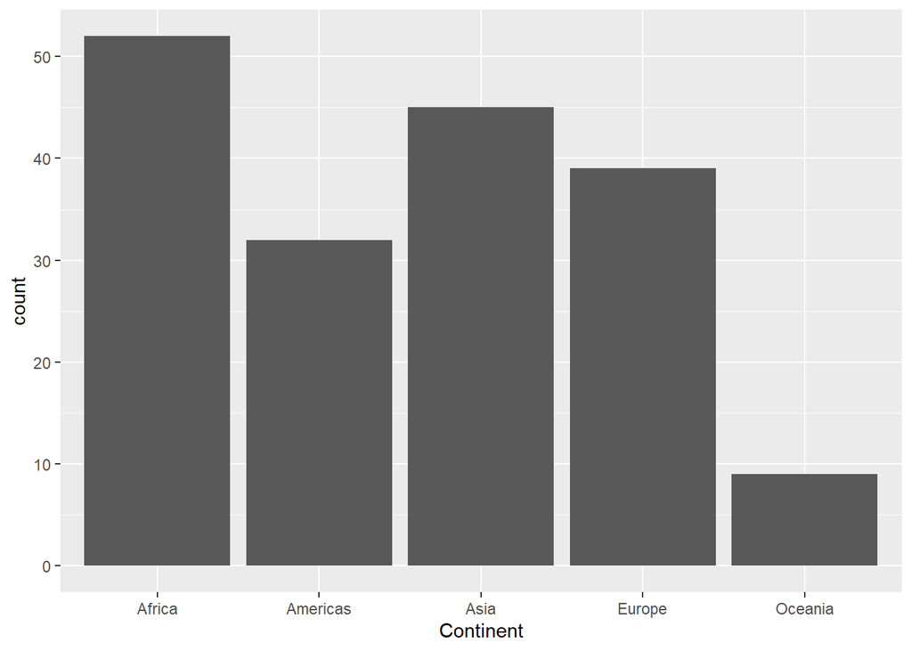

```r
countries$Continent <- countrycode(sourcevar = countries[, "Country"],
                            origin = "country.name",
                            destination = "continent")

ggplot(data=countries,aes(x=Continent)) + geom_bar()
```

**aes** means aesthetics and determines the look of the graph. Here, we are specifying that the Continent column is mapped to the x-axis of the layer. **geom_bar** function means that we are expecting the plot to be a bar chart.

This is only using a few of the possible components of a layer. Each geom function has its own statistical transformation (in this case, count) and position by default.

We can change this transformation using **stat**.We can also colour the bars using **fill** and specify bar dimensions using **width**.

```r
library("dplyr")
```

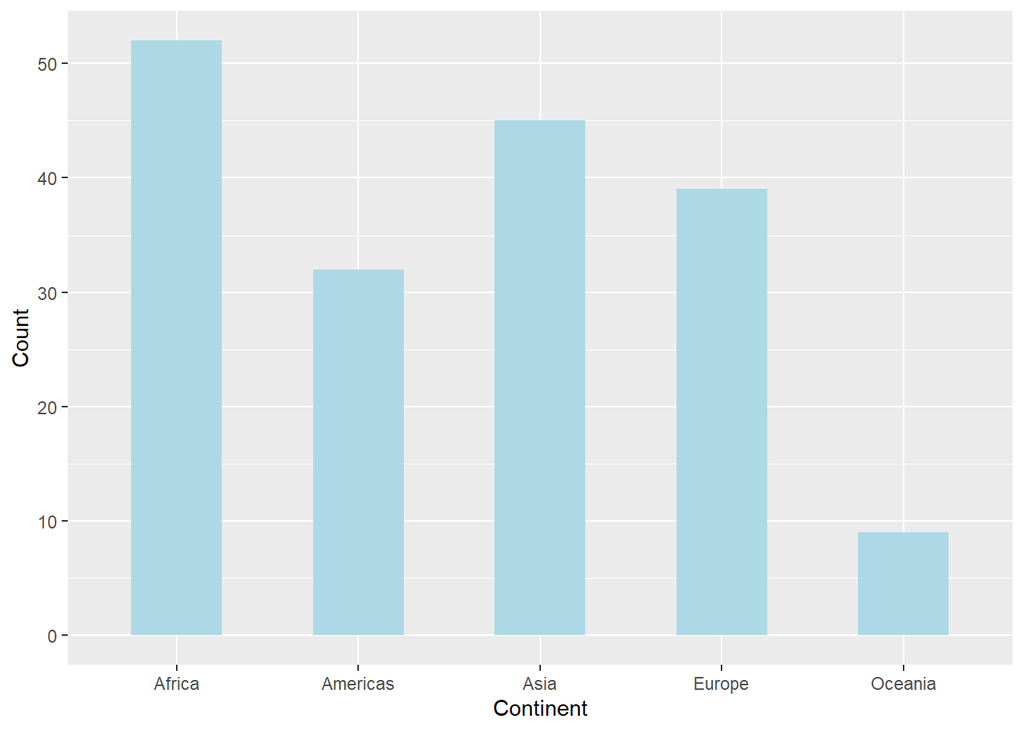

```r
df = countries %>% group_by(Continent) %>% summarize(Count=n())

ggplot(data=df,aes(x=Continent, y=Count)) + geom_bar(stat="identity", fill="lightblue", width=0.5)
```

### Overlay Layers

For a line plot, we use **geom_line**. Note that geom_line connects lines in the same group. Hence, we need to specify **group=1**.

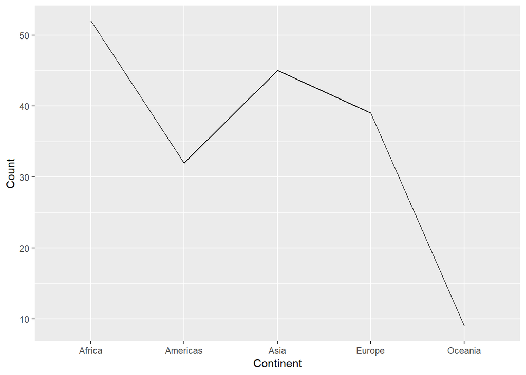

```r
ggplot(data=df, aes(x=Continent, y=Count)) + geom_line(group=1)
```

We can use **geom_point** for a scatter plot and use **size**, **shape**, and fill to specify the look of our points.

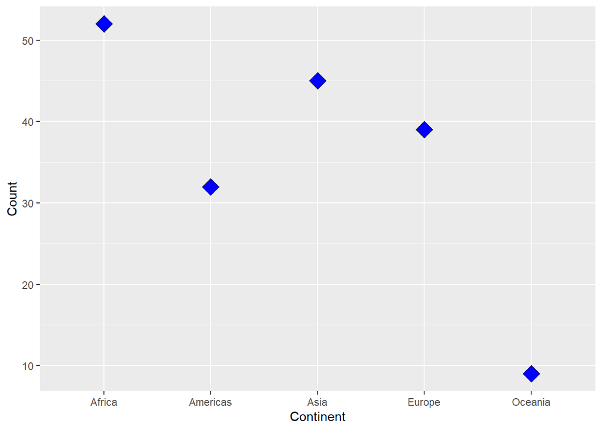

```r
ggplot(data=df, aes(x=Continent, y=Count)) + geom_point(size=5, shape=23, fill="blue")
```

To overlay the two, we can just add the two geom functions:

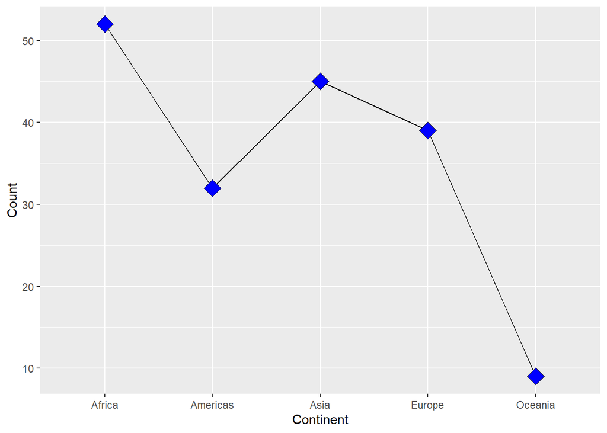

```r
ggplot(data=df, aes(x=Continent, y=Count)) + geom_line(group=1) +
  geom_point(size=5, shape=23, fill="blue")
```

This works in this case because the data here shares the same data source. However, ggplot2 also offers flexibility for plots of different data like so:

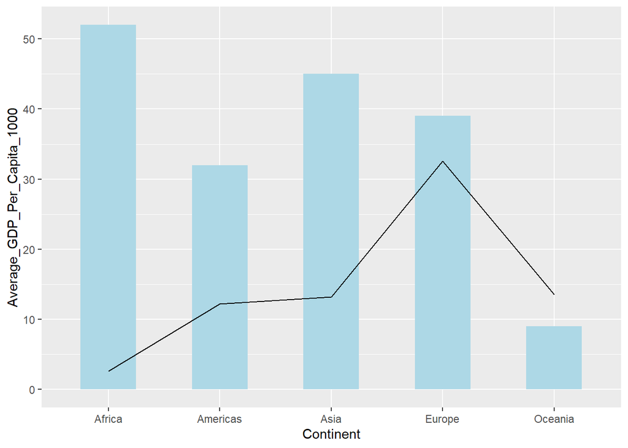

```r
df = countries %>% group_by(Continent) %>% summarize(Average_GDP_Per_Capita_1000=mean(GDP_Per_Capita)/1000)

ggplot() + geom_bar(data=countries, aes(x=Continent), fill="lightblue", width=0.5) +
  geom_line(data=df, aes(x=Continent, y=Average_GDP_Per_Capita_1000), group=1)
```

Note that the sequence of geom functions determines the order in which the layers are added. Since the geom_line is added last, it is layered on the top.

### Scaling

GDP per Capita vs Life Expectancy:

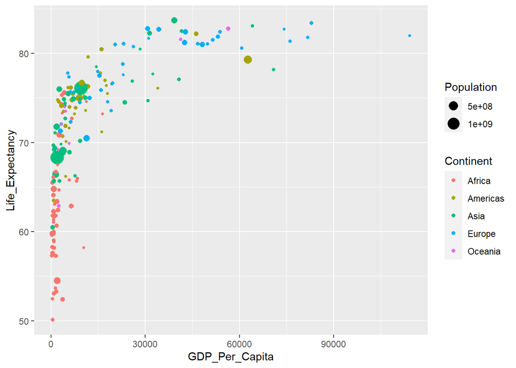

```r
ggplot(data=countries, aes(x=GDP_Per_Capita, y=Life_Expectancy,
                           size=Population, color=Continent)) + geom_point()
```

This relationship is non-linear (likely logarithmic). We can rescale the GDP per Capita using **scale_x_log10**:

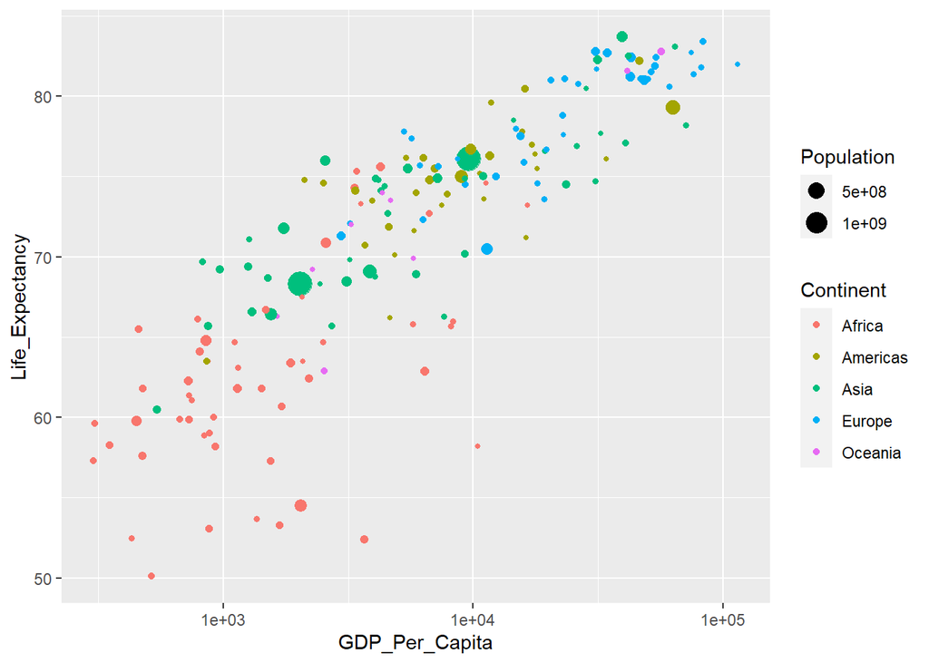

```r
ggplot(data=countries, aes(x=GDP_Per_Capita, y=Life_Expectancy, size=Population,
                           color=Continent)) + geom_point() + scale_x_log10()
```

We can also scale other factors (e.g. point size). In this case, we resize the population to a logarithmic scale using **scale_size_continuous**:

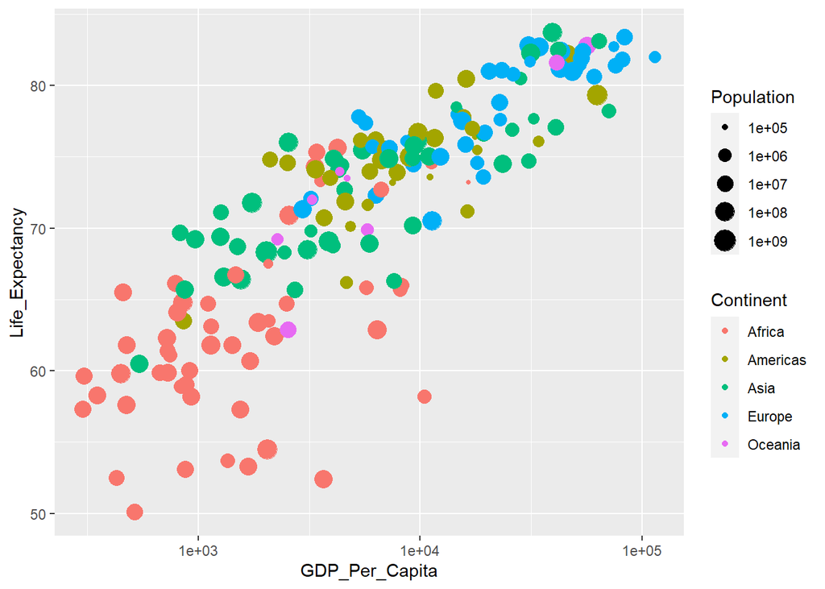

```r
ggplot(data=countries, aes(x=GDP_Per_Capita, y=Life_Expectancy,
                           size=Population, color=Continent)) +
  geom_point() + scale_x_log10() + scale_size_continuous(trans="log10")
```

We can also set the colours of the points manually using **scale_color_manual**:

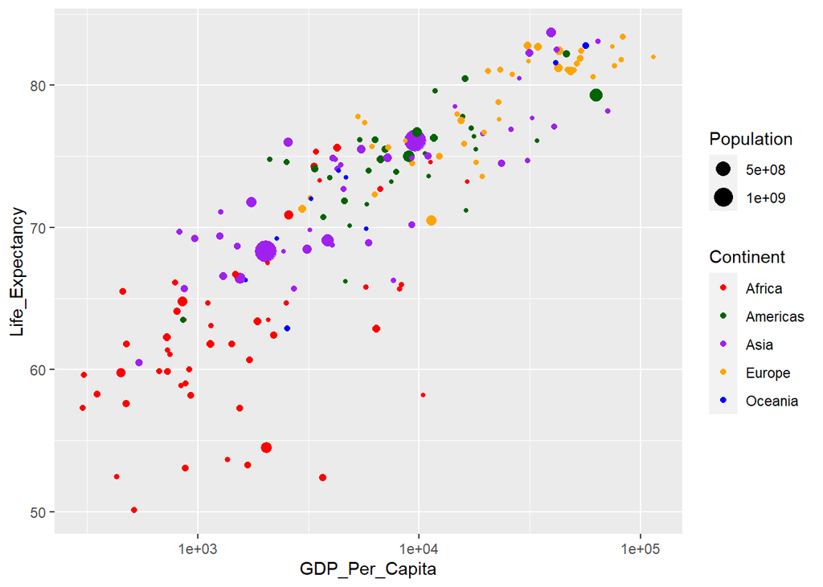

```r
ggplot(data=countries, aes(x=GDP_Per_Capita, y=Life_Expectancy,
                           size=Population, color=Continent)) +
  geom_point() + scale_x_log10() + scale_color_manual(values=c("red", "darkgreen", "purple", "orange", "blue"))
```

### Coordinate System

By default, ggplot2 uses the Cartesian coordinate system. We can switch to a Polar system using **coord_polar**:

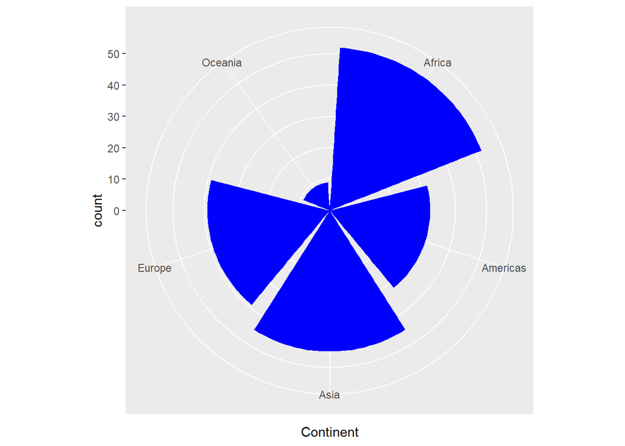

```r
ggplot(data=countries,aes(x=Continent)) + geom_bar(fill="blue") + coord_polar()
```

### Graph Components

1. Plot title (Text)
2. Axis Title (Text)
3. Tick Label (Text)
4. Background Panel (Rectangle)
5. Grid Lines (Line)
6. Others (found under ?theme)

Each of the 3 types can be manipulated using the **element_text**, **element_rect** and **element_line** functions respectively:

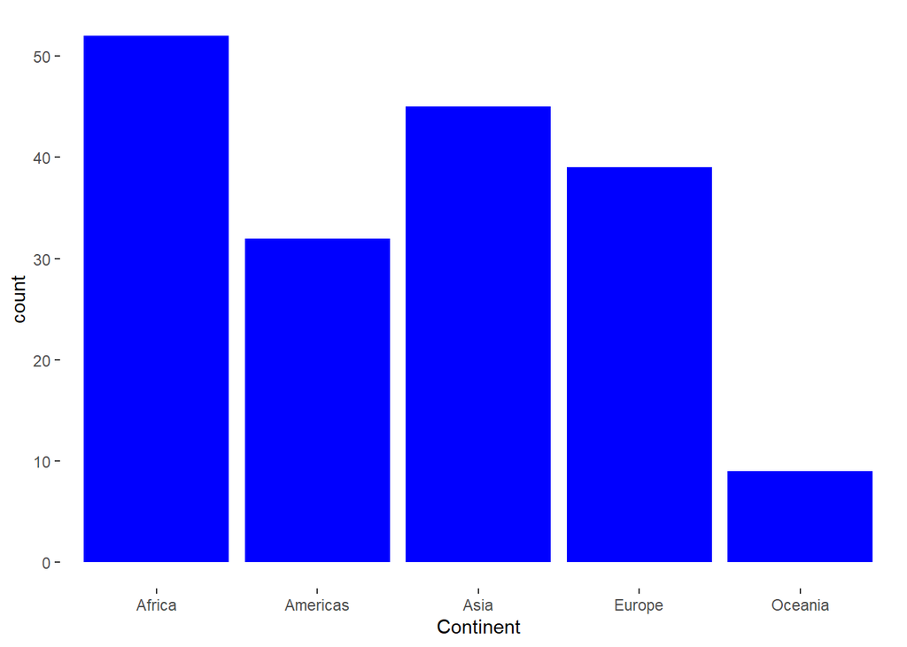

```r
## change bg to white
ggplot(data=countries,aes(x=Continent)) + geom_bar(fill="blue") +
  theme(panel.background=element_rect(fill="white"))
```

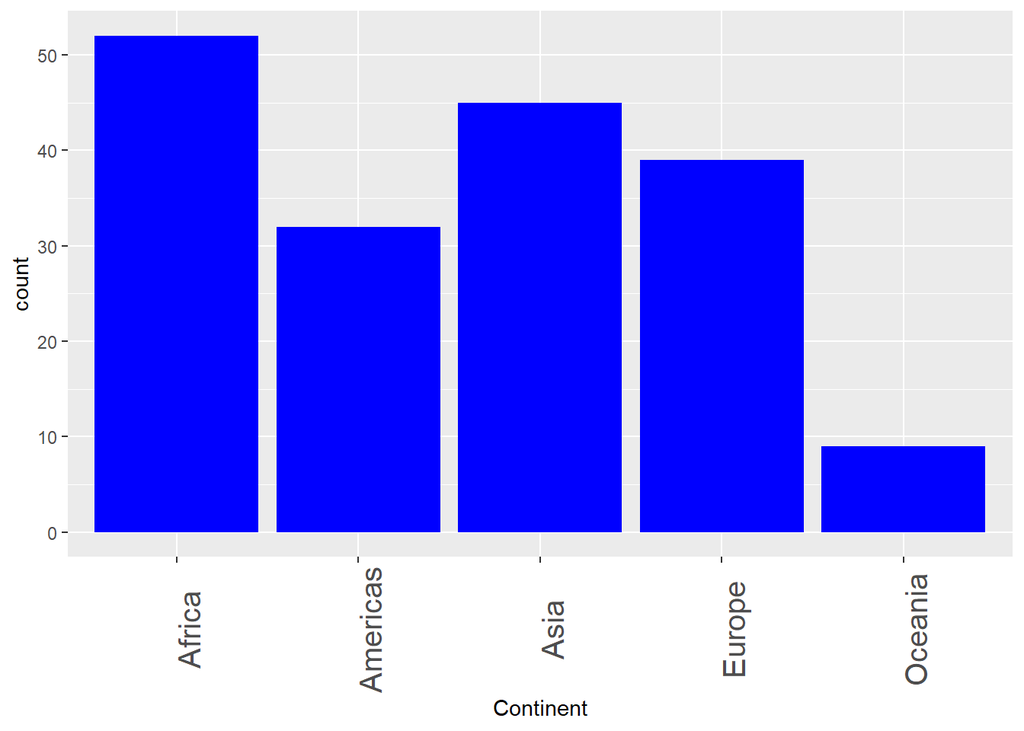

```r
## change orientation of tick labels
ggplot(data=countries,aes(x=Continent)) + geom_bar(fill="blue") +
  theme(axis.text.x=element_text(size=15, angle=90))
```

We can also adopt a theme:

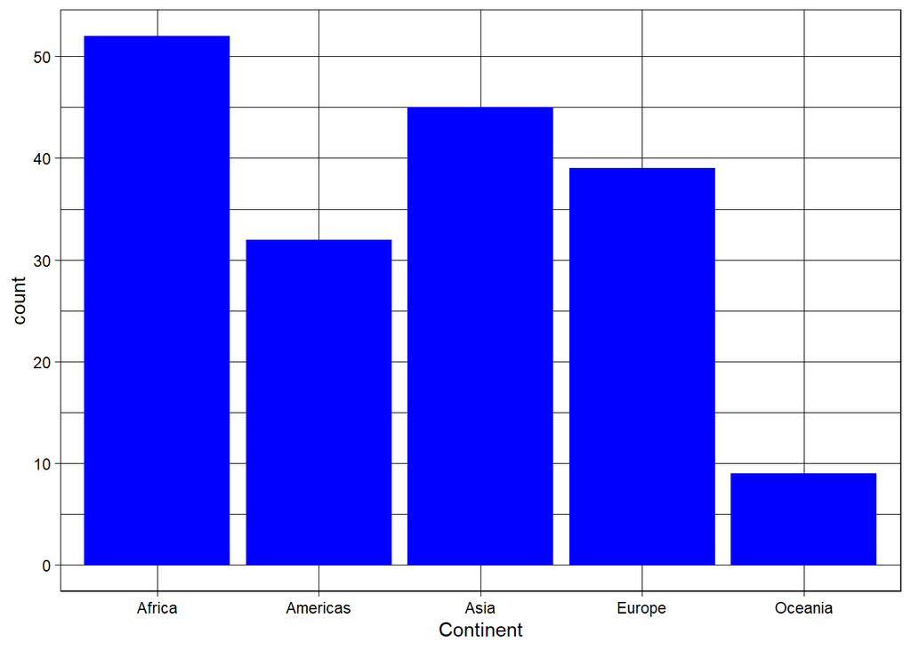

```r
ggplot(data=countries,aes(x=Continent)) + geom_bar(fill="blue") + theme_linedraw()
```

### Faceting

```r
library("gapminder")
head(gapminder)
```

```
## # A tibble: 6 x 6
##   country     continent  year lifeExp      pop gdpPercap
##   <fct>       <fct>     <int>   <dbl>    <int>     <dbl>
## 1 Afghanistan Asia       1952    28.8  8425333      779.
## 2 Afghanistan Asia       1957    30.3  9240934      821.
## 3 Afghanistan Asia       1962    32.0 10267083      853.
## 4 Afghanistan Asia       1967    34.0 11537966      836.
## 5 Afghanistan Asia       1972    36.1 13079460      740.
## 6 Afghanistan Asia       1977    38.4 14880372      786.
```

gapminder contains the data for multiple years. If we plot it as such, the data becomes very messy. Instead, we can facet the data by year using **facet_wrap** to produce multiple side-by-side plots:

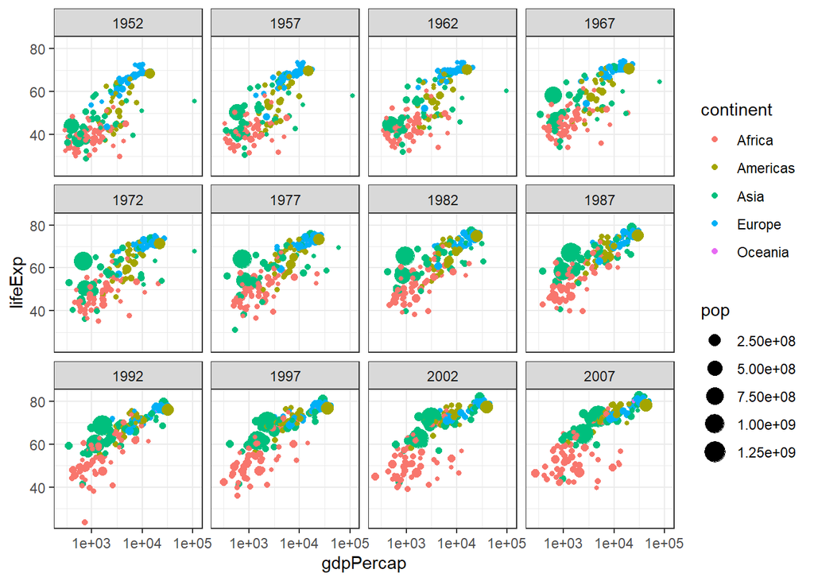

```r
ggplot(data=gapminder, aes(x=gdpPercap, y=lifeExp, size=pop, color=continent)) +
  geom_point() + scale_x_log10() + theme_bw() + facet_wrap(~year)
```

### Positioning

- identity (default for most geoms)
- jitter (default for geom_jitter)
- dodge (default of geom_boxplot)
- stack (default of geom_bar, geom_histogram, geom_area)
- fill (useful for geom_bar, geom_histogram, geom_area)

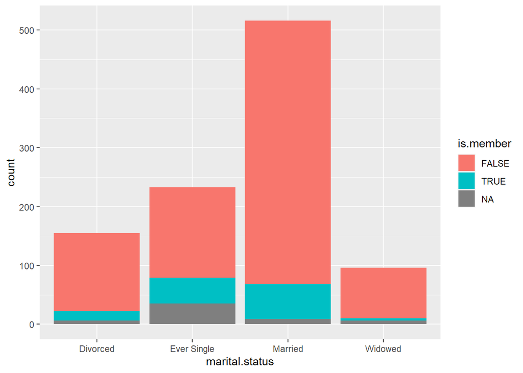

```r
custdata = read.csv("./Data/Customers.csv")

ggplot(custdata) + geom_bar(aes(x=marital.status, fill=is.member))
```

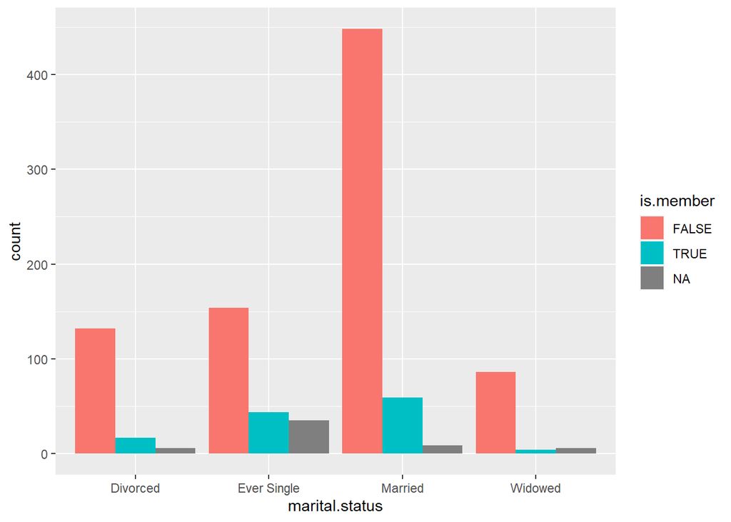

```r
ggplot(custdata) + geom_bar(aes(x=marital.status, fill=is.member), position="dodge")
```

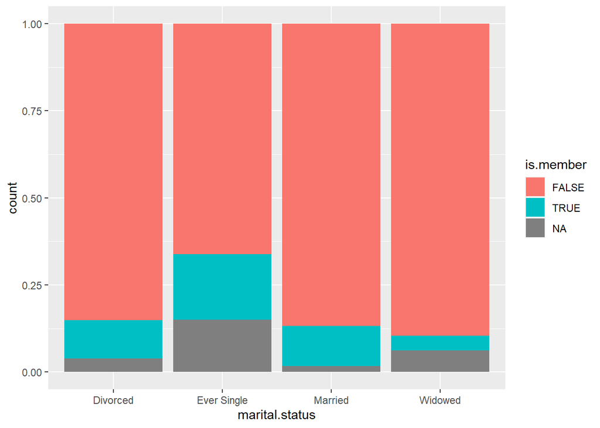

```r
ggplot(custdata) + geom_bar(aes(x=marital.status, fill=is.member), position="fill")
```

## gganimate

Animate the changes in plot by year using **transition_time**

```r
library("gganimate")
library("png")
library("gifski")
```

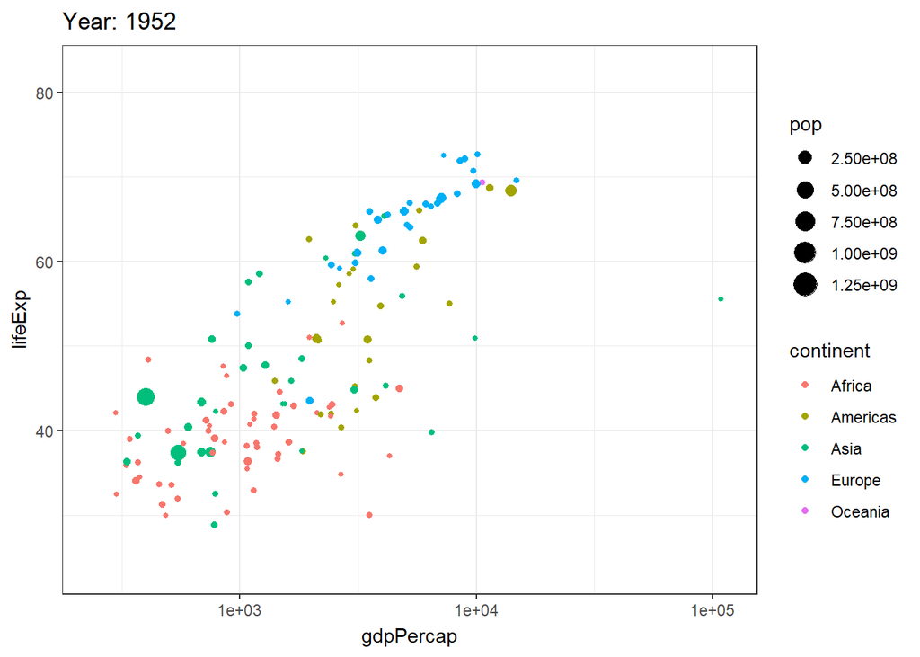

```r
p = ggplot(data=gapminder, aes(x=gdpPercap, y=lifeExp, size=pop, color=continent)) +
  geom_point() + scale_x_log10() + theme_bw()

p + transition_time(year) + labs(title="Year: {frame_time}")
```